# Chem277B: Machine Learning Algorithms

## Homework assignment #6: Clustering

```python
import numpy as np
import pandas as pd
import math
import matplotlib.pyplot as plt
import torch
import torch.nn as nn
import torch.optim as optim
from sklearn.model_selection import train_test_split, KFold
import warnings
from sklearn.cluster import DBSCAN
from sklearn import cluster, datasets, mixture
from sklearn.preprocessing import StandardScaler
from itertools import cycle, islice
from pylab import *
import seaborn as sns

np.random.seed(0)
sns.set()
```

### 1. KMeans.

(a) By normalizing the data and visualizing their correlation, I noticed that all three types are correlated by features `C` and `D`. In addition, amides and ethers are correlated by features `A` and `C`, but phenols are not correlated by these two features.

```python
compounds = pd.read_csv('compounds.csv')
compounds.head()
```

|  | A | B | C | D | type |
| --- | --- | --- | --- | --- | --- |
| 0 | 6.4 | 2.9 | 4.3 | 1.3 | amide |
| 1 | 5.7 | 4.4 | 1.5 | 0.4 | phenol |
| 2 | 6.7 | 3.0 | 5.2 | 2.3 | ether |
| 3 | 5.8 | 2.8 | 5.1 | 2.4 | ether |
| 4 | 6.4 | 3.2 | 5.3 | 2.3 | ether |

```python
compounds.loc[:,'A':'D'].max(axis=0)
```

```
A    7.9
B    4.4
C    6.9
D    2.5
dtype: float64
```

```python
compounds.loc[:,'A':'D'] = compounds.loc[:,'A':'D'] / compounds.loc[:,'A':'D'].max(axis=0)
compounds.head()
```

|  | A | B | C | D | type |
| --- | --- | --- | --- | --- | --- |
| 0 | 0.810127 | 0.659091 | 0.623188 | 0.52 | amide |
| 1 | 0.721519 | 1.000000 | 0.217391 | 0.16 | phenol |
| 2 | 0.848101 | 0.681818 | 0.753623 | 0.92 | ether |
| 3 | 0.734177 | 0.636364 | 0.739130 | 0.96 | ether |
| 4 | 0.810127 | 0.727273 | 0.768116 | 0.92 | ether |

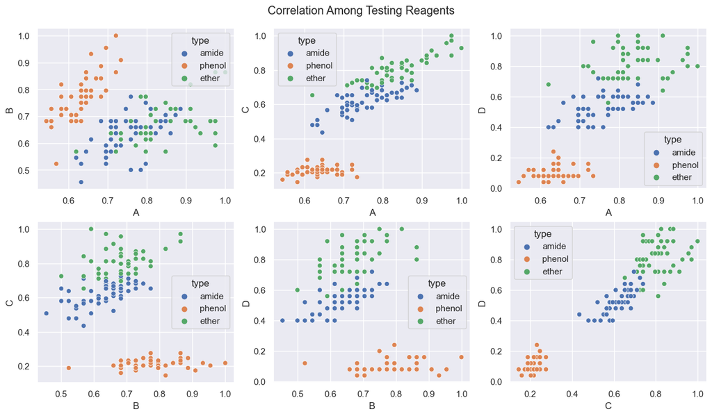

```python
fig, axes = plt.subplots(2, 3, figsize=(15,8))
fig.suptitle('Correlation Among Testing Reagents', y=0.93)
sns.scatterplot(ax=axes[0,0], data = compounds, x='A', y='B', hue='type')
sns.scatterplot(ax=axes[0,1], data = compounds, x='A', y='C', hue='type')
sns.scatterplot(ax=axes[0,2], data = compounds, x='A', y='D', hue='type')
sns.scatterplot(ax=axes[1,0], data = compounds, x='B', y='C', hue='type')
sns.scatterplot(ax=axes[1,1], data = compounds, x='B', y='D', hue='type')
sns.scatterplot(ax=axes[1,2], data = compounds, x='C', y='D', hue='type')
```

(b) I have finished the KMeans clustering codes as shown below. I also chose K = 2, 3, 4 and generated 3 new columns in the compounds dataframe. After visualizing the codes, I noticed that K = 2 is actually the best clustering because each cluster is very distant apart from the other in all the correlation graphs.

```python
class KMeans():
    def __init__(self, K, maximum_iters=100):
        # K: number of clusters to be created
        # distance matrix is Eucledian distance
        self.K = K
        self.maximum_iters = maximum_iters

    def cluster(self, input_points):
        """ Do KMeans clustering
            input_points: np.array shape(ndata, nfeatures).
            Each feature is assumed to be normalized within range of [0,1]
        """
        centroids = np.random.random((self.K, input_points.shape[1]))
        assignments = np.zeros(input_points.shape[0], dtype = np.int32)
        new_assignments = self.create_new_assignments(centroids, input_points)

        # restart if run into bad initialization
        # Comment out this part for Q1.(d)
        if len(np.unique(new_assignments)) < self.K:
            return self.cluster(input_points)

        n_iters = 1
        while (new_assignments != assignments).any() and n_iters < self.maximum_iters:
            ### Compute the centroid given new assignment ###
            centroids = np.array([input_points[new_assignments == k].mean(axis=0) for \
                                 k in range(self.K)])
            assignments = new_assignments
            ### Update the assignment with current centroids ###
            new_assignments = self.create_new_assignments(centroids, input_points)
            if len(np.unique(new_assignments))< self.K:
                warnings.warn('At least one centroid vanishes')
            n_iters += 1
            if n_iters == self.maximum_iters:
                print("Warning: Maximum number of iterations reached!")

        return new_assignments


    def create_new_assignments(self, centroids, data_points):
        """ Assign each datapoint to its nearest centroid.
        centroid: 2d array of the current centroid for each cluster
        data_points: 2d arrays recording the features of each data point.
        """
        ###Compute the distances that stores the Eucledian distances between each datapoints and the centroid ###
        #shape (ndata,ncentroid)
        distances = np.sqrt(((data_points[:, np.newaxis, :] - centroids)**2).sum(axis = -1))
        new_assignments = np.argmin(distances, axis=-1)
        return new_assignments
```

```python
compounds_ndarray = np.array(compounds.loc[:,'A':'D'])
KMeans_2 = KMeans(2, maximum_iters=100)
compounds['type_2'] = KMeans_2.cluster(compounds_ndarray)
KMeans_3 = KMeans(3, maximum_iters=100)
compounds['type_3'] = KMeans_3.cluster(compounds_ndarray)
KMeans_4 = KMeans(4, maximum_iters=100)
compounds['type_4'] = KMeans_4.cluster(compounds_ndarray)
compounds.head()
```

|  | A | B | C | D | type | type_2 | type_3 | type_4 |
| --- | --- | --- | --- | --- | --- | --- | --- | --- |
| 0 | 0.810127 | 0.659091 | 0.623188 | 0.52 | amide | 1 | 2 | 3 |
| 1 | 0.721519 | 1.000000 | 0.217391 | 0.16 | phenol | 0 | 0 | 0 |
| 2 | 0.848101 | 0.681818 | 0.753623 | 0.92 | ether | 1 | 1 | 2 |
| 3 | 0.734177 | 0.636364 | 0.739130 | 0.96 | ether | 1 | 1 | 2 |
| 4 | 0.810127 | 0.727273 | 0.768116 | 0.92 | ether | 1 | 1 | 2 |

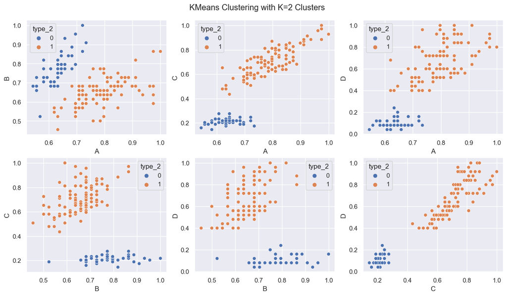

```python
fig, axes = plt.subplots(2, 3, figsize=(15,8))
fig.suptitle('KMeans Clustering with K=2 Clusters', y=0.93)
sns.scatterplot(ax=axes[0,0], data = compounds, x='A', y='B', hue='type_2')
sns.scatterplot(ax=axes[0,1], data = compounds, x='A', y='C', hue='type_2')
sns.scatterplot(ax=axes[0,2], data = compounds, x='A', y='D', hue='type_2')
sns.scatterplot(ax=axes[1,0], data = compounds, x='B', y='C', hue='type_2')
sns.scatterplot(ax=axes[1,1], data = compounds, x='B', y='D', hue='type_2')
sns.scatterplot(ax=axes[1,2], data = compounds, x='C', y='D', hue='type_2')
```

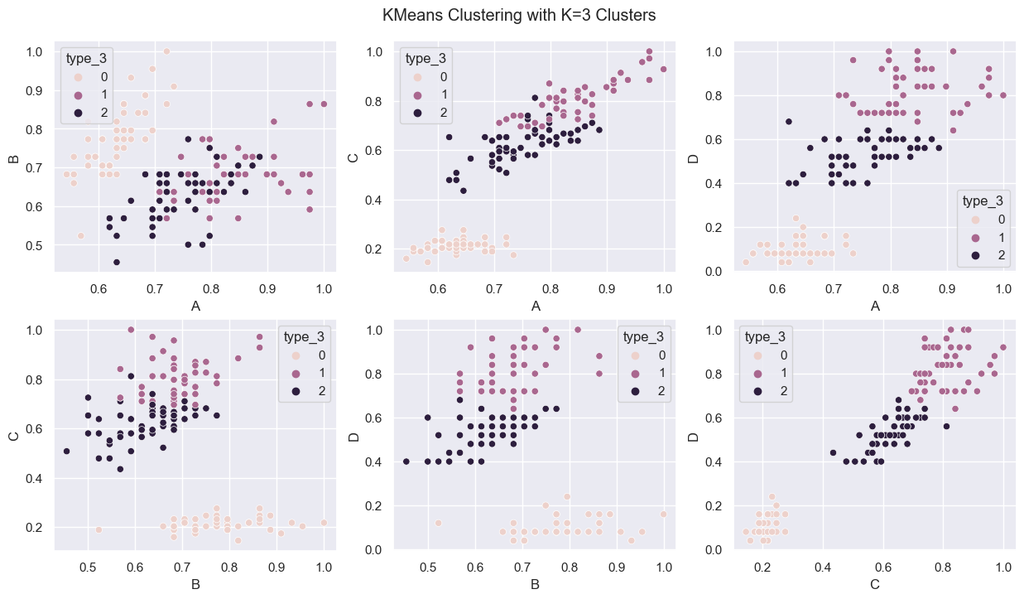

```python
fig, axes = plt.subplots(2, 3, figsize=(15,8))
fig.suptitle('KMeans Clustering with K=3 Clusters', y=0.93)
sns.scatterplot(ax=axes[0,0], data = compounds, x='A', y='B', hue='type_3')
sns.scatterplot(ax=axes[0,1], data = compounds, x='A', y='C', hue='type_3')
sns.scatterplot(ax=axes[0,2], data = compounds, x='A', y='D', hue='type_3')
sns.scatterplot(ax=axes[1,0], data = compounds, x='B', y='C', hue='type_3')
sns.scatterplot(ax=axes[1,1], data = compounds, x='B', y='D', hue='type_3')
sns.scatterplot(ax=axes[1,2], data = compounds, x='C', y='D', hue='type_3')
```

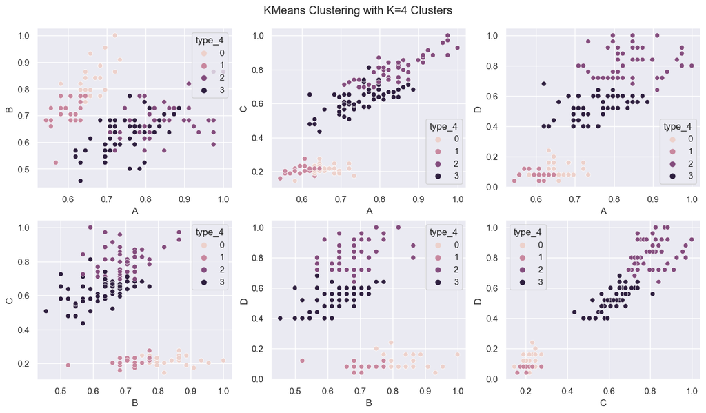

```python
fig, axes = plt.subplots(2, 3, figsize=(15,8))
fig.suptitle('KMeans Clustering with K=4 Clusters', y=0.93)
sns.scatterplot(ax=axes[0,0], data = compounds, x='A', y='B', hue='type_4')
sns.scatterplot(ax=axes[0,1], data = compounds, x='A', y='C', hue='type_4')
sns.scatterplot(ax=axes[0,2], data = compounds, x='A', y='D', hue='type_4')
sns.scatterplot(ax=axes[1,0], data = compounds, x='B', y='C', hue='type_4')
sns.scatterplot(ax=axes[1,1], data = compounds, x='B', y='D', hue='type_4')
sns.scatterplot(ax=axes[1,2], data = compounds, x='C', y='D', hue='type_4')
```

(c) I ran the provided validation function on the K=3 clustering and the true label. The clustering is pretty close to the original labeling, giving the following results:

Class 2 - amide: 48 out of 49 are classified correctly

When I visualized the results using Seaborn, I think the KMeans clustering is actually better than the true labeling, especially for correlations between `A` & `D`, `B` & `D` and `C` & `D`.

```python
def validate(y_hat,y):
    """print accuracy of prediction for each class for the compounds dataset
    yhat: np.array shape(ndata). Your prediction of classes
    y: np.array of str shape(ndata). data labels / groudn truths.
    """
    # correct classification
    compounds = np.unique(y) # should be ['amide','phenol','ether'] for compounds dataset
    clusters =[np.where((y==c)) for c in compounds]
    pred_class = np.unique(y_hat)

    #remove -1 for noise point in DBSCAN
    pred_class= np.delete(pred_class,np.where(pred_class==-1))
    assert len(pred_class) == len(compounds), f'y_hat has less or more than {len(compounds)} classes:{pred_class}'

    for i in range(3):
        #loop over solutions
        counts=[]
        scores=[]
        for j in range(3):
            #loop over clusters of true assignments
            sol_i= np.where((y_hat==pred_class[i]))
            counts.append(len(np.intersect1d(sol_i, clusters[j])))
            scores.append(counts[-1]/len(clusters[j]))
        idx = np.argmax(scores)
        print(f'Class {pred_class[i]} - {compounds[idx]}: {counts[idx]} out \
of {np.count_nonzero(clusters[idx])} are classified correctly')
```

```python
validate(compounds['type_3'], compounds['type'])
```

```
Class 0 - phenol: 50 out of 50 are classified correctly
Class 1 - ether: 46 out of 50 are classified correctly
Class 2 - amide: 48 out of 49 are classified correctly
```

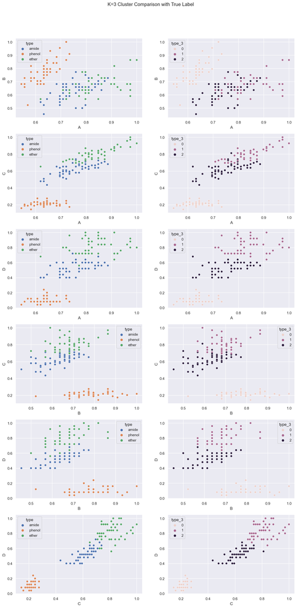

```python
fig, axes = plt.subplots(6, 2, figsize=(15,30))
fig.suptitle('K=3 Cluster Comparison with True Label', y=0.93)
sns.scatterplot(ax=axes[0,0], data = compounds, x='A', y='B', hue='type')
sns.scatterplot(ax=axes[0,1], data = compounds, x='A', y='B', hue='type_3')
sns.scatterplot(ax=axes[1,0], data = compounds, x='A', y='C', hue='type')
sns.scatterplot(ax=axes[1,1], data = compounds, x='A', y='C', hue='type_3')
sns.scatterplot(ax=axes[2,0], data = compounds, x='A', y='D', hue='type')
sns.scatterplot(ax=axes[2,1], data = compounds, x='A', y='D', hue='type_3')
sns.scatterplot(ax=axes[3,0], data = compounds, x='B', y='C', hue='type')
sns.scatterplot(ax=axes[3,1], data = compounds, x='B', y='C', hue='type_3')
sns.scatterplot(ax=axes[4,0], data = compounds, x='B', y='D', hue='type')
sns.scatterplot(ax=axes[4,1], data = compounds, x='B', y='D', hue='type_3')
sns.scatterplot(ax=axes[5,0], data = compounds, x='C', y='D', hue='type')
sns.scatterplot(ax=axes[5,1], data = compounds, x='C', y='D', hue='type_3')
```

Therefore, it is important to check whether all K clusters have at least one data point assigned to them. If not, we need to restart the clustering with a new set of randomly initialized centroids.

I found the following possible solutions: 1. KMeans++, which choose initial centroids uniformly from the dataset to make sure thei will be assigned data points. 2. Instead of K centroids, we choose 2K or 3K centroids and discard the empty centroids to keep K centroids with data points assigned.

```python
class KMeans_4():
    def __init__(self, K, maximum_iters=100):
        # K: number of clusters to be created
        # distance matrix is Eucledian distance
        self.K = K
        self.maximum_iters = maximum_iters

    def cluster(self, input_points):
        """ Do KMeans clustering
            input_points: np.array shape(ndata, nfeatures).
            Each feature is assumed to be normalized within range of [0,1]
        """
        centroids = np.random.random((self.K, input_points.shape[1]))
        assignments = np.zeros(input_points.shape[0], dtype = np.int32)
        new_assignments = self.create_new_assignments(centroids, input_points)

        # restart if run into bad initialization
        # Comment out this part for Q1.(d)
#         if len(np.unique(new_assignments)) < self.K:
#             return self.cluster(input_points)

        n_iters = 1
        while (new_assignments != assignments).any() and n_iters < self.maximum_iters:
            ### Compute the centroid given new assignment ###
            centroids = np.array([input_points[new_assignments == k].mean(axis=0) for \
                                 k in range(self.K)])
            assignments = new_assignments
            ### Update the assignment with current centroids ###
            new_assignments = self.create_new_assignments(centroids, input_points)
            if len(np.unique(new_assignments))< self.K:
                warnings.warn('At least one centroid vanishes')
            n_iters += 1
            if n_iters == self.maximum_iters:
                print("Warning: Maximum number of iterations reached!")

        return new_assignments


    def create_new_assignments(self, centroids, data_points):
        """ Assign each datapoint to its nearest centroid.
        centroid: 2d array of the current centroid for each cluster
        data_points: 2d arrays recording the features of each data point.
        """
        ###Compute the distances that stores the Eucledian distances between each datapoints and the centroid ###
        #shape (ndata,ncentroid)
        distances = np.sqrt(((data_points[:, np.newaxis, :] - centroids)**2).sum(axis = -1))
        new_assignments = np.argmin(distances, axis=-1)
        return new_assignments
```

```python
KMeans_4_1 = KMeans_4(4, maximum_iters=100)
compounds['type_4_1'] = KMeans_4_1.cluster(compounds_ndarray)
KMeans_4_2 = KMeans_4(4, maximum_iters=100)
compounds['type_4_2'] = KMeans_4_2.cluster(compounds_ndarray)
KMeans_4_3 = KMeans_4(4, maximum_iters=100)
compounds['type_4_3'] = KMeans_4_3.cluster(compounds_ndarray)
KMeans_4_4 = KMeans_4(4, maximum_iters=100)
compounds['type_4_4'] = KMeans_4_4.cluster(compounds_ndarray)
KMeans_4_5 = KMeans_4(4, maximum_iters=100)
compounds['type_4_5'] = KMeans_4_5.cluster(compounds_ndarray)
compounds.head()
```

|  | A | B | C | D | type | type_2 | type_3 | type_4 | type_4_1 | type_4_2 | type_4_3 | type_4_4 | type_4_5 |
| --- | --- | --- | --- | --- | --- | --- | --- | --- | --- | --- | --- | --- | --- |
| 0 | 0.810127 | 0.659091 | 0.623188 | 0.52 | amide | 1 | 2 | 3 | 1 | 1 | 1 | 0 | 1 |
| 1 | 0.721519 | 1.000000 | 0.217391 | 0.16 | phenol | 0 | 0 | 0 | 1 | 1 | 1 | 0 | 1 |
| 2 | 0.848101 | 0.681818 | 0.753623 | 0.92 | ether | 1 | 1 | 2 | 1 | 1 | 1 | 0 | 1 |
| 3 | 0.734177 | 0.636364 | 0.739130 | 0.96 | ether | 1 | 1 | 2 | 1 | 1 | 1 | 0 | 1 |
| 4 | 0.810127 | 0.727273 | 0.768116 | 0.92 | ether | 1 | 1 | 2 | 1 | 1 | 1 | 0 | 1 |

### 2. DBSCAN.

With the set hyperparameters, I have altogether 103 core points, 26 border points, and 21 noise points.

Compared to KMeans, DBSCAN seems less flexible and less effective. It results in a lot of noise points that can't be defined. With the compounds dataset, I prefer KMeans.

```python
compounds_DBSCAN = compounds.loc[:,'A':'D'].values
db = DBSCAN(eps=0.09, min_samples=5)
clustering = db.fit(compounds_DBSCAN)
# Cluster labels for each point in the dataset given to fit().  Noisy samples are given the label -1.
clustering.labels_
```

```
array([ 0, -1,  1, -1,  1,  2, -1,  1,  0,  1,  0, -1, -1,  1,  2,  2,  1,
        1,  0,  2,  2,  1, -1,  1,  2,  1,  2,  2,  2,  1, -1,  2,  1,  2,
        0,  0,  2,  1,  0,  2,  0,  0, -1,  1,  2,  0,  1,  1,  0, -1, -1,
        0,  1, -1,  1,  0, -1,  0,  1,  2,  2,  0,  2,  0,  1,  2,  0,  2,
        0,  0, -1,  2,  0,  1,  0,  2,  1,  0,  0,  0,  0,  2,  2,  0,  1,
        0, -1,  0,  0,  0,  0, -1,  2,  2,  2,  2,  1,  1,  1,  2,  0,  0,
        0,  0,  0,  2,  2,  2,  2,  0, -1,  2,  2, -1,  0,  1,  2,  2,  2,
       -1,  2,  2,  2,  0, -1, -1,  1,  0,  1,  2,  1,  0,  1,  0,  1, -1,
        2,  0,  2,  0,  1,  2,  0,  2,  0,  2,  1,  0,  0,  0])
```

```python
# Indices of core samples.
clustering.core_sample_indices_
```

```
array([  0,   2,   4,   5,   7,   8,   9,  10,  13,  14,  15,  17,  18,
        19,  20,  21,  24,  25,  26,  27,  28,  29,  31,  32,  36,  37,
        38,  39,  40,  41,  43,  44,  45,  46,  47,  54,  55,  57,  58,
        59,  60,  61,  62,  63,  65,  66,  67,  69,  71,  72,  73,  74,
        75,  76,  77,  78,  79,  81,  82,  83,  84,  85,  89,  90,  92,
        93,  99, 101, 103, 104, 105, 106, 107, 108, 109, 111, 112, 114,
       115, 116, 117, 118, 120, 121, 122, 126, 128, 129, 130, 131, 132,
       133, 134, 136, 137, 139, 141, 142, 143, 145, 146, 148, 149])
```

```python
# Number of core samples.
len(clustering.core_sample_indices_)
```

```
103
```

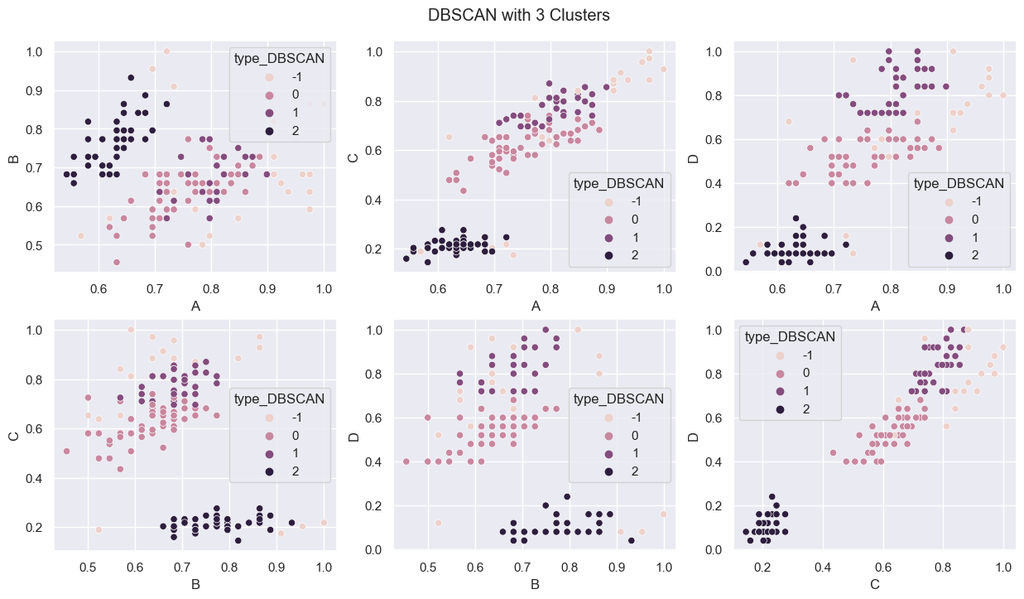

```python
compounds['type_DBSCAN'] = clustering.labels_
fig, axes = plt.subplots(2, 3, figsize=(15,8))
fig.suptitle('DBSCAN with 3 Clusters', y=0.93)
sns.scatterplot(ax=axes[0,0], data = compounds, x='A', y='B', hue='type_DBSCAN')
sns.scatterplot(ax=axes[0,1], data = compounds, x='A', y='C', hue='type_DBSCAN')
sns.scatterplot(ax=axes[0,2], data = compounds, x='A', y='D', hue='type_DBSCAN')
sns.scatterplot(ax=axes[1,0], data = compounds, x='B', y='C', hue='type_DBSCAN')
sns.scatterplot(ax=axes[1,1], data = compounds, x='B', y='D', hue='type_DBSCAN')
sns.scatterplot(ax=axes[1,2], data = compounds, x='C', y='D', hue='type_DBSCAN')
```

```python
# Write a function to acquire core, noise and border points
core_points_mask = np.zeros_like(clustering.labels_, dtype=bool)
core_points_mask[clustering.core_sample_indices_] = True
noise_points_mask = (clustering.labels_ == -1)
border_points_mask = ~(core_points_mask | noise_points_mask)
core_points = compounds_DBSCAN[core_points_mask]
border_points = compounds_DBSCAN[border_points_mask]
noise_points = compounds_DBSCAN[noise_points_mask]
print(len(core_points), len(border_points), len(noise_points))
```

```
103 26 21
```

(b) In the case of noisy moon dataset, DBSCAN work much better than KMeans.

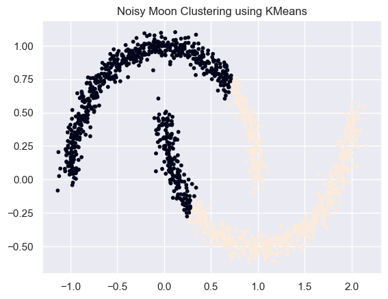

```python
# Clustering the noisy moon dataset using KMeans
K_moon = KMeans(2, maximum_iters=100)
moon_clustering_k = K_moon.cluster(X)
moon_clustering_k
plt.scatter(X[:, 0], X[:, 1], s=10,c=moon_clustering_k)
plt.title('Noisy Moon Clustering using KMeans')
```

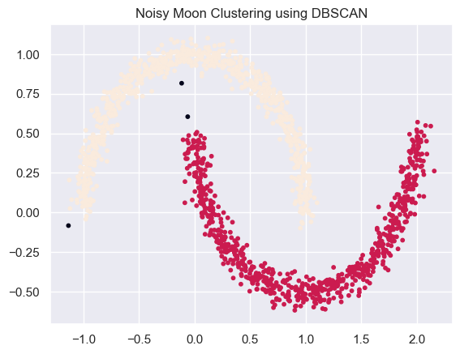

```python
# Clustering the noisy moon dataset using DBSCAN
db_moon = DBSCAN(eps=0.1, min_samples=10)
clustering_moon = db_moon.fit(X)
# Cluster labels for each point in the dataset given to fit().  Noisy samples are given the label -1.
clustering_moon.labels_
plt.scatter(X[:, 0], X[:, 1], s=10,c=clustering_moon.labels_)
plt.title('Noisy Moon Clustering using DBSCAN')
```